[OHI Science](http://ohi-science.org) | [Citation policy](http://ohi-science.org/citation-policy/)

# OHI: Pressures - Commercial Fishing

Compiled on Tue Feb 2 16:31:17 2016 by afflerbach

# 1 Summary

The Sea Around Us Project calculated catch by gear type globally for each 0.5 degree cell. This catch was split into five gear categories (demersal destructive, high and low pelagic, and high & low bycatch demersal non-destructive).

These layers were previously used for Cumulative Impacts analysis and were provided in 2008. They have not been updated since.

For the Ocean Health Index, the commercial fishing pressure layers are created by combining these 5 gear categories into high and low bycatch gears and then calculating total catch in tons/km2 standardized by productivity.

The standardization prevents areas of high catch in highly productive areas from being penalized more than high catches in low productivity areas.

# 2 Updates from previous assessment

The 2015 assessment used the same data from SAUP as all previous assessments, but used the primary productivity associated with each of the catch-years. Previously, standardizing by primary productivity was not documented and likely was only done by using a single representative average across all years.

# 3 Data Source

**Reference**: Catch data provided by the [Sea Around Us Project (SAUP)](http://www.seaaroundus.org/) in 2008. This has not been updated by SAUP since 2008. Primary productivity data came from [VGPM](http://orca.science.oregonstate.edu/1080.by.2160.monthly.hdf.vgpm.m.chl.m.sst.php)

**Downloaded**: 2008

**Description**: Catch (tons) per 0.5 degree cell in 5 distinct gear categories (demersal destructive, pelagic high & low bycatch, demersal non-destructive high & low bycatch)

**Native data resolution**: Catch data from SAUP is 0.5 degree cells, and productivity data is 0.16 degree cells

**Time range**: 2003-2010

**Format**: Catch data was provided by SAUP as GeoTIFF files (.tif) and the VGPM data was provided as space-delimited {longitude latitude variable} text files (.xyz).

# 4 Methods

*NOTE: Data prep information for the VGPM productivity data can be found [here](https://github.com/OHI-Science/ohiprep/tree/master/globalprep/VGPM_primary_productivity/v2015)

**These global raster data files are too large for GitHub storage and therefore are held on an NCEAS server. This script points to that server (Neptune) rather than data held on GitHub.**

```r
source('../../../src/R/common.R')

rm(list=ls())

library(raster)
library(rasterVis)
library(dplyr)
library(RColorBrewer)
library(rgdal)
library(ggplot2)

cols = rev(colorRampPalette(brewer.pal(11, 'Spectral'))(255)) # rainbow color scheme



dir_N = c('Windows' = '//neptune.nceas.ucsb.edu/data_edit',
          'Darwin'  = '/Volumes/data_edit',
          'Linux'   = '/var/data/ohi')[[ Sys.info()[['sysname']] ]]


# set tmp directory
tmpdir=file.path(dir_N,'home_big/afflerbach/R_raster_tmp')
dir.create(tmpdir, showWarnings=F)
rasterOptions(tmpdir=tmpdir)

# set mollweide projection
moll_crs = CRS("+proj=moll +lon_0=0 +x_0=0 +y_0=0 +ellps=WGS84 +units=m +no_defs")

#define colors for plotting
cols      = rev(colorRampPalette(brewer.pal(11, 'Spectral'))(255)) # rainbow color scheme
myTheme <- rasterTheme(region = rev(brewer.pal('Spectral', n = 11)))

ocean = raster(file.path(dir_N, 'model/GL-NCEAS-Halpern2008/tmp/ocean.tif'))
```

## 4.1 Read in SAUP catch by gear data

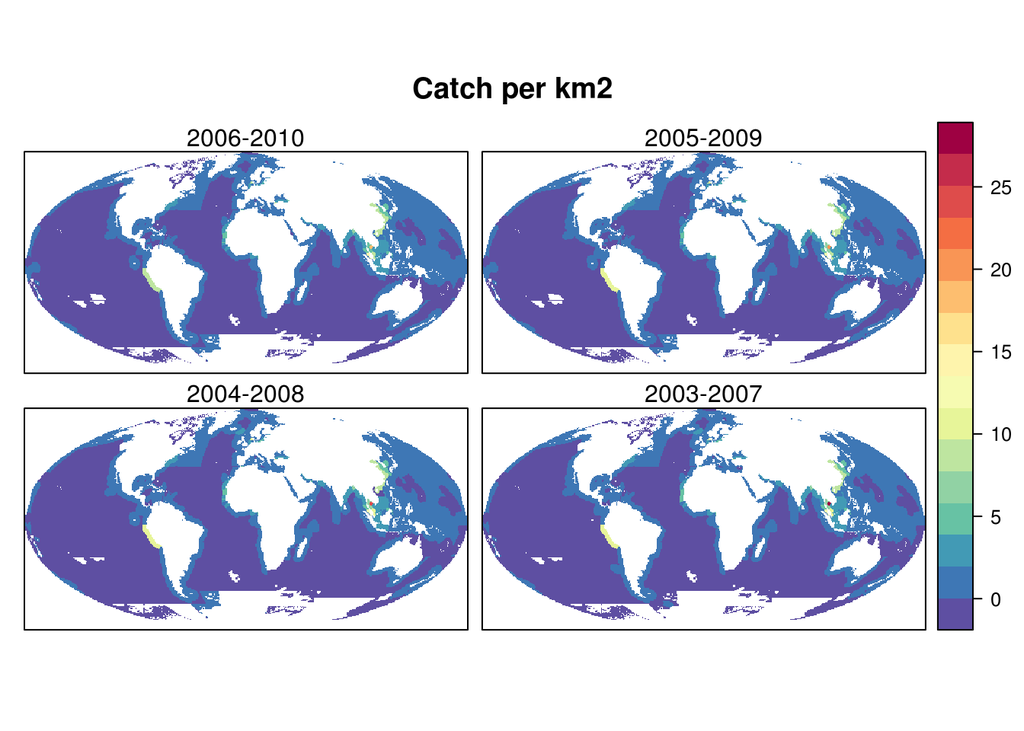

```r
# Fish catch at 1km

catch_06_10 = raster(file.path(dir_N,'git-annex/globalprep/Pressures_fishing/v2015/catch_km_06_10.tif'))
catch_05_09 = raster(file.path(dir_N,'git-annex/globalprep/Pressures_fishing/v2015/catch_km_05_09.tif'))
catch_04_08 = raster(file.path(dir_N,'git-annex/globalprep/Pressures_fishing/v2015/catch_km_04_08.tif'))
catch_03_07 = raster(file.path(dir_N,'git-annex/globalprep/Pressures_fishing/v2015/catch_km_03_07.tif'))

#Primary productivity at 1km - aggregate to time periods


s = stack(catch_06_10,catch_05_09, catch_04_08, catch_03_07)

levelplot(s,par.settings=myTheme,strip.background = list(col = 'transparent'),scales=list(draw=FALSE),
          layout=c(2,2), main = 'Catch per km2',
          strip.border = list(col = 'transparent'),names.attr = c('2006-2010','2005-2009','2004-2008','2003-2007'))
```

## 4.2 Primary productivity

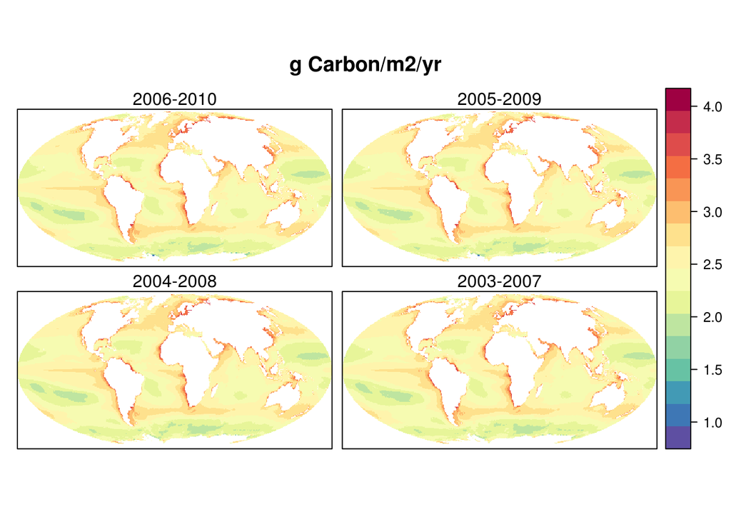

```r
#Aggregate to the appropriate time periods

#npp = list.files(file.path(dir_N,'git-annex/globalprep/VGPM_primary_productivity/v_2015/output'),pattern='annual_mean_npp_2',full.names=T)

# npp_06_10 = calc(stack(npp[substr(npp,113,116) %in% 2006:2010]),fun=function(x){mean(x,na.rm=T)},progress='text')%>%
#              projectRaster(.,crs=moll_crs,progress='text',over=T)%>%
#               resample(.,ocean,method='ngb',filename='v2015/npp/npp_06_10.tif')

npp_06_10 = raster(file.path(dir_N,'git-annex/globalprep/Pressures_fishing/v2015/npp/npp_06_10.tif'))

# npp_05_09 = calc(stack(npp[substr(npp,113,116) %in% 2005:2009]),fun=function(x){mean(x,na.rm=T)},progress='text')%>%
#                projectRaster(.,crs=moll_crs,progress='text',over=T)%>%
#                 resample(.,ocean,method='ngb',filename='v2015/npp/npp_05_09.tif')

npp_05_09 = raster(file.path(dir_N,'git-annex/globalprep/Pressures_fishing/v2015/npp/npp_05_09.tif'))

# npp_04_08 = calc(stack(npp[substr(npp,113,116) %in% 2004:2008]),fun=function(x){mean(x,na.rm=T)},progress='text')%>%
#              projectRaster(.,crs=moll_crs,progress='text',over=T)%>%
#               resample(.,ocean,method='ngb',filename='v2015/npp/npp_04_08.tif')

npp_04_08 = raster(file.path(dir_N,'git-annex/globalprep/Pressures_fishing/v2015/npp/npp_04_08.tif'))

# npp_03_07 = calc(stack(npp[substr(npp,113,116) %in% 2003:2007]),fun=function(x){mean(x,na.rm=T)},progress='text')%>%
#              projectRaster(.,crs=moll_crs,progress='text',over=T)%>%
#               resample(.,ocean,method='ngb',filename='v2015/npp/npp_03_07.tif')

npp_03_07 = raster(file.path(dir_N,'git-annex/globalprep/Pressures_fishing/v2015/npp/npp_03_07.tif'))

n = stack(npp_06_10,npp_05_09, npp_04_08, npp_03_07)

levelplot(n,par.settings=myTheme,strip.background = list(col = 'transparent'),scales=list(draw=FALSE),
          layout=c(2,2), main = 'g Carbon/m2/yr',
          strip.border = list(col = 'transparent'),names.attr = c('2006-2010','2005-2009','2004-2008','2003-2007'))
```

## 4.3 Bring in catch by gear (high and low bycatch) at 1km2

These rasters were created in this dataprep.R script

```r
gear_hb = raster(file.path(dir_N,'git-annex/globalprep/Pressures_fishing/v2015/gear_prop_hb_moll_1km_ocean.tif'))
gear_lb = raster(file.path(dir_N,'git-annex/globalprep/Pressures_fishing/v2015/gear_prop_lb_moll_1km_ocean.tif'))
```

## 4.4 Standardize catch by primary productivity

This scales catch so that catches in areas of low productivity are weighted higher than areas of high productivity

```r
catch_npp_06_10 = overlay(catch_06_10,npp_06_10,fun=function(x,y){x/y},progress='text',filename=file.path(dir_N,'git-annex/globalprep/Pressures_fishing/v2015/catch_npp_06_10.tif'))
catch_npp_05_09 = overlay(catch_05_09,npp_05_09,fun=function(x,y){x/y},progress='text',filename=file.path(dir_N,'git-annex/globalprep/Pressures_fishing/v2015/catch_npp_05_09.tif'))
catch_npp_04_08 = overlay(catch_04_08,npp_04_08,fun=function(x,y){x/y},progress='text',file.path(dir_N,'git-annex/globalprep/Pressures_fishing/v2015/catch_npp_04_08.tif'))
catch_npp_03_07 = overlay(catch_03_07,npp_03_07,fun=function(x,y){x/y},progress='text',filename=file.path(dir_N,'git-annex/globalprep/Pressures_fishing/v2015/catch_npp_03_07.tif'))
```

## 4.5 Divide catch by primary productivity then multiply by gear proportions

```r
out_06_10_hb = overlay(catch_npp_06_10,gear_hb,fun=function(x,y){x*y},progress='text',
                       filename='v2015/output/catch_06_10_npp_hb_raw.tif',overwrite=T)
out_06_10_lb = overlay(catch_npp_06_10,gear_lb,fun=function(x,y){x*y},progress='text',
                       filename='v2015/output/catch_06_10_npp_lb_raw.tif',overwrite=T)

out_05_09_hb = overlay(catch_npp_05_09,gear_hb,fun=function(x,y){x*y},progress='text',
                       filename='v2015/output/catch_05_09_npp_hb_raw.tif',overwrite=T)
out_05_09_lb = overlay(catch_npp_05_09,gear_lb,fun=function(x,y){x*y},progress='text',
                       filename='v2015/output/catch_05_09_npp_lb_raw.tif',overwrite=T)

out_04_08_hb = overlay(catch_npp_04_08,gear_hb,fun=function(x,y){x*y},progress='text',
                       filename='v2015/output/catch_04_08_npp_hb_raw.tif',overwrite=T)
out_04_08_lb = overlay(catch_npp_04_08,gear_lb,fun=function(x,y){x*y},progress='text',
                       filename='v2015/output/catch_04_08_npp_lb_raw.tif',overwrite=T)

out_03_07_hb = overlay(catch_npp_03_07,gear_hb,fun=function(x,y){x*y},progress='text',
                       filename='v2015/output/catch_03_07_npp_hb_raw.tif',overwrite=T)
out_03_07_lb = overlay(catch_npp_03_07,gear_lb,fun=function(x,y){x*y},progress='text',
                       filename='v2015/output/catch_03_07_npp_lb_raw.tif',overwrite=T)
```

## 4.6 Rescale using 99.99 quantile

```r
fishing.pressures = list.files("v2015/output",full.names=T)

for (i in 1:length(fishing.pressures)){

  print(i)

  r    = raster(fishing.pressures[i])
  yrs  = substr(names(r),7,11)
  gear = substr(names(r),17,18)

  # look at logged data

  r_log = calc(r,fun=function(x){log(x+1)},progress='text')

  ref = quantile(r_log,prob=0.9999)

  resc_log =  calc(r_log,fun=function(x){ifelse(x>ref,1,x/ref)},progress='text')

  writeRaster(resc_log,filename=paste0('v2015/output/catch_',yrs,'_npp_',gear,'_rescaled.tif'),overwrite=T)

}
```